# Gaussian process regression and classification

Paul DW Kirk

14/02/2022

```r
library(tidyverse)
library(mvtnorm)
library(gplite)
# Set working directory
# setwd("your/directory/here")  https://cran.r-project.org/web/packages/gplite/vignettes/quickstart.html
```

# GP regression

The below provides a similar example to the one considered in the lecture:

```r
set.seed(10)
n <- 6
x  <- matrix(seq(0,1,length.out = n), ncol=1)
y  <- sin(2*pi*x) + rnorm(n,0,1e-1)

ggplot() +
  geom_point(aes(x=x, y=y), size=2) +
  xlab('x') + ylab('y') + xlim(-.5, 1.5)+ ylim(-3, 2.5)

#Specify the GP model we want to use:
gp <- gp_init(
  cfs = cf_sexp(),  # A squared exponential (aka Gaussian aka RBF) kernel
  lik = lik_gaussian(), # Assume Gaussian distributed errors
  method = method_full() # Use the full covariance (i.e. do not approximate)
)

#Now fit the model to the data:
gp <- gp_optim(gp, x, y)

# compute the predictive mean and variance in a grid of points
xt   <- seq(-.5,1.5,len=150)
pred <- gp_pred(gp, xt, var=T)

# visualize
mu <- pred$mean
lb <- pred$mean - 2*sqrt(pred$var)
ub <- pred$mean + 2*sqrt(pred$var)
ggplot() +
  geom_ribbon(aes(x=xt, ymin=lb, ymax=ub), fill='lightgray') +
  geom_line(aes(x=xt, y=mu), size=0.5) +
  geom_point(aes(x=x, y=y), size=2) +
  xlab('x') + ylab('y')+ xlim(-.5, 1.5)+ ylim(-3, 2.5)

ndraws <- 20
draws  <- gp_draw(gp, xt, draws=ndraws)
pp     <- ggplot() + xlab('x') + ylab('y')
for (i in 1:ndraws) {
  pp <- pp + geom_line(data=data.frame(x=xt, y=draws[,i]), aes(x=x,y=y), color='darkgray')
}
plot(pp + geom_point(aes(x=x,y=y), color='black', size=2) + xlim(-.5, 1.5)+ ylim(-3, 2.5))
```

[output not shown]

# The Squared Exponential covariance function

The example below explores how the GP prior changes as we vary the hyperparameters of the SE covariance function

```r
set.seed(10)
#Specify the GP model we want to use:

#We consider 4 different settings of the hyper parameters
# lscale is the length scale, magn is the amplitude:
gp03_1 <- gp_init(
  cfs = cf_sexp(lscale = 0.3, magn = 1),  # A squared exponential (aka Gaussian aka RBF) kernel
)

gp005_3 <- gp_init(
  cfs = cf_sexp(lscale = 0.05, magn = 3),  # A squared exponential (aka Gaussian aka RBF) kernel
)

gp09_3 <- gp_init(
  cfs = cf_sexp(lscale = 0.9, magn = 3),  # A squared exponential (aka Gaussian aka RBF) kernel
)

gp03_3 <- gp_init(
  cfs = cf_sexp(lscale = 0.3, magn = 3),  # A squared exponential (aka Gaussian aka RBF) kernel
)



# Specify the test points at which we will evaluate the GP prior:
xt <- seq(-.5,1.5,len=150)

# Specify the number of draws from the prior:
ndraws <- 20

# And draw from the prior!
draws <- gp_draw(gp03_1, xt, draws=ndraws)

# Now plot:
pp <- ggplot() + xlab('x') + ylab('y')
for (i in 1:ndraws) {
  pp <- pp + geom_line(data=data.frame(x=xt, y=draws[,i]), aes(x=x,y=y), color='darkgray')
}
pp + ylim(-10, 10)


#Repeat for the other hyperparameter settings:
draws <- gp_draw(gp03_3, xt, draws=ndraws)
pp <- ggplot() + xlab('x') + ylab('y')
for (i in 1:ndraws) {
  pp <- pp + geom_line(data=data.frame(x=xt, y=draws[,i]), aes(x=x,y=y), color='darkgray')
}
pp + ylim(-10, 10)

#And again:
draws <- gp_draw(gp005_3, xt, draws=ndraws)
pp <- ggplot() + xlab('x') + ylab('y')
for (i in 1:ndraws) {
  pp <- pp + geom_line(data=data.frame(x=xt, y=draws[,i]), aes(x=x,y=y), color='darkgray')
}
pp + ylim(-10, 10)

#And one more time:
draws <- gp_draw(gp09_3, xt, draws=ndraws)
pp <- ggplot() + xlab('x') + ylab('y')
for (i in 1:ndraws) {
  pp <- pp + geom_line(data=data.frame(x=xt, y=draws[,i]), aes(x=x,y=y), color='darkgray')
}
pp + ylim(-10, 10)

#What are the effects of changing the hyperparameters?

#Try exploring different choices of covariance function, e.g. cf_lin, cf_matern32
#A full list of the available options is provided in ?cf
#Note that different covariance functions will generally have different hyperparameters
#Explore how the priors change with different cov functions *and* diff hypers
```

[output not shown]

# Combining covariance functions

This section shows an example of how to combine several covariance functions into the model. We use the AirPassengers dataset for demonstration.

Let’s first load and visualize the data. We shall use the last 24 months as a test set and compare our model predictions to that.

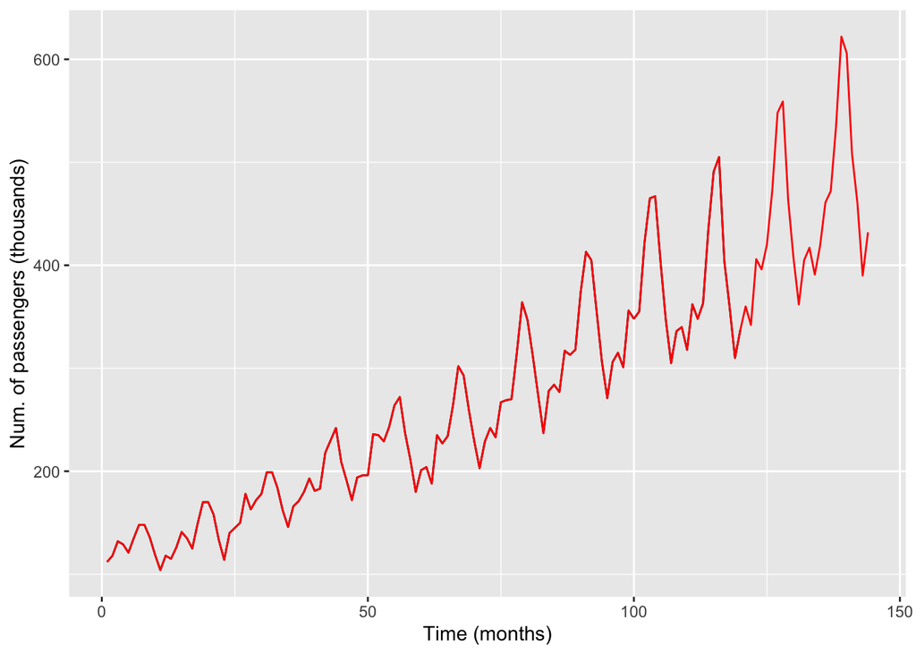

```r
y_all <- datasets::AirPassengers
x_all <- seq_along(y_all)

# hold out 2 years as a test set
nt <- 24
n <- length(x_all) - nt
x <- x_all[1:n]
y <- y_all[1:n]
xt <- x_all #tail(x_all, nt)
yt <- y_all #tail(y_all, nt)

ggplot() +
  geom_line(aes(x=x,y=y), color='black') +
  geom_line(aes(x=xt,y=yt), color='red') +
  xlab('Time (months)') + ylab('Num. of passengers (thousands)')
```

The data clearly has some systematic variability related to a yearly cycle (period of 12 months). To account for this, we use a periodic kernel (with a fixed period of 12 months) multiplied by a squared exponential with a rather large length-scale to obtain a quasi-periodic covariance function. To account for the rising trend, we use a combination of linear and constant covariance functions. To obtain a better fit, we fit the model on logarithm of the target variable.

The following code sets up the model. Here we use initial values for the parameters that are rather close to the optimal ones to make the optimization faster, but in practice it is usually not necessary to have such precise initial guess (the intial values can have effect, though, if the hyperparameter posterior is multimodal).

```r
# take a log transformation to get a more stationary process
yscaled <- log(y)

# set up the model
cf0 <- cf_const()
cf1 <- cf_lin()
cf2 <- cf_periodic(
  period=12
)

cf3 <- cf_sexp(lscale=100)

#cfs <- list(cf0, cf1)   # (1) Try using this covariance function instead!
cfs <- list(cf0, cf1, cf2)  # (2) Try using this covariance function instead!  How do the predictions change?
cfs <- list(cf0, cf1, cf2*cf3)

gp <- gp_init(cfs, lik=lik_gaussian(sigma=0.05))
```

Optimize the hyperparameters

```r
gp <- gp_optim(gp, x, yscaled, maxiter = 500,
  restarts = 2, verbose = FALSE)  #Set verbose = F to reduce the printed output!
```

Visualize the predictions

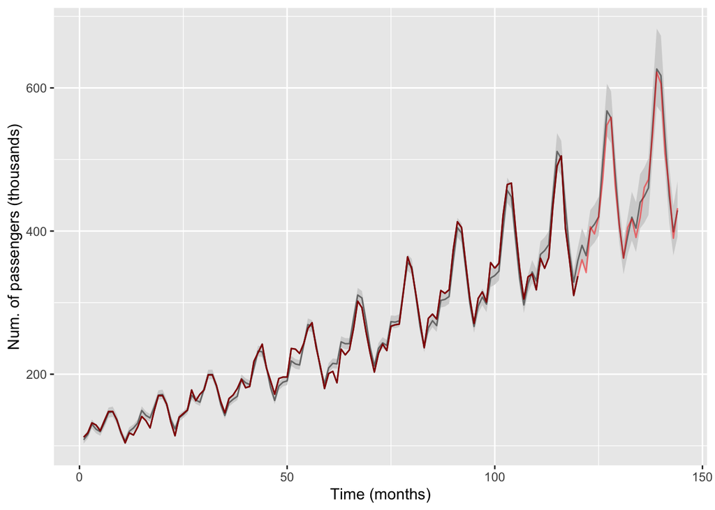

```r
pred_scaled <- gp_pred(gp, xt, var=T)

pred <- exp(pred_scaled$mean)
pred_lb <- exp(pred_scaled$mean - 2*sqrt(pred_scaled$var))
pred_ub <- exp(pred_scaled$mean + 2*sqrt(pred_scaled$var))

ggplot() +
  geom_ribbon(aes(x=xt, ymin=pred_lb, ymax=pred_ub), fill='lightgray') +
  geom_line(aes(x=xt, y=pred), color='black', alpha=0.5) +
  geom_line(aes(x=x, y=y), color='black') +
  geom_line(aes(x=xt, y=yt), color='red', alpha=0.5) +
  xlab('Time (months)') + ylab('Num. of passengers (thousands)')
```

The model’s predictions match very closely to the actual observations in the last two years we left out before model fitting.

# Classification

We illustrate with a synthetic 2d classification example.

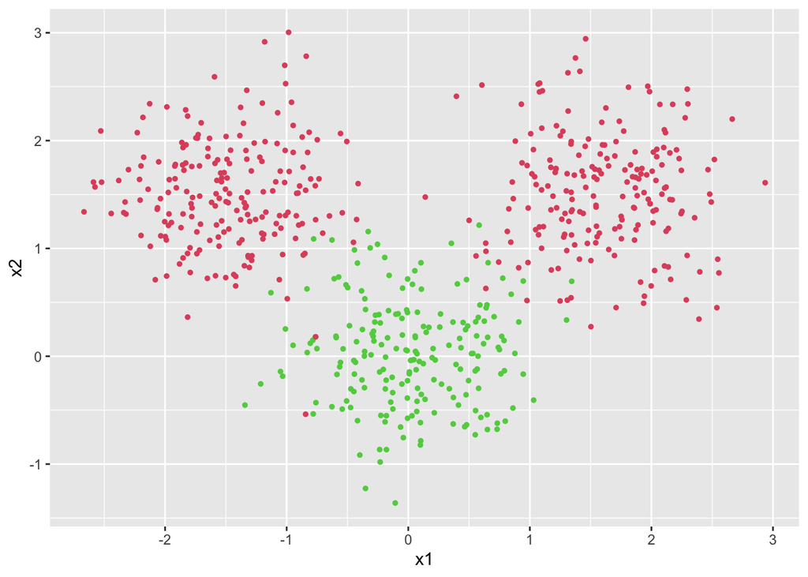

```r
# create synthetic 2d binary classification data
set.seed(2)
n <- 600
n_per_cluster <- n/3
d <- 2
x <- 0.5*cbind( matrix(rnorm(n_per_cluster*d), nrow=d) + c(3,3),
                matrix(rnorm(n_per_cluster*d), nrow=d) - c(0,0),
                matrix(rnorm(n_per_cluster*d), nrow=d) + c(-3,3))
x <- t(x)
y <- c(rep(0,n_per_cluster), rep(1,n_per_cluster), rep(0,n_per_cluster))

# plot
ggplot() +
  geom_point(data=data.frame(x=x[,1],y=x[,2]), aes(x=x,y=y), color=y+2, size=1) +
  xlab('x1') + ylab('x2')
```

```r
# fit the model
gp <- gp_init(
  lik = lik_bernoulli(), # This is necessary to indicate that we are fitting a classifier
  cfs = cf_sexp()
  )
gp <- gp_optim(gp, x, y)
```

Let’s visualize the predictions.

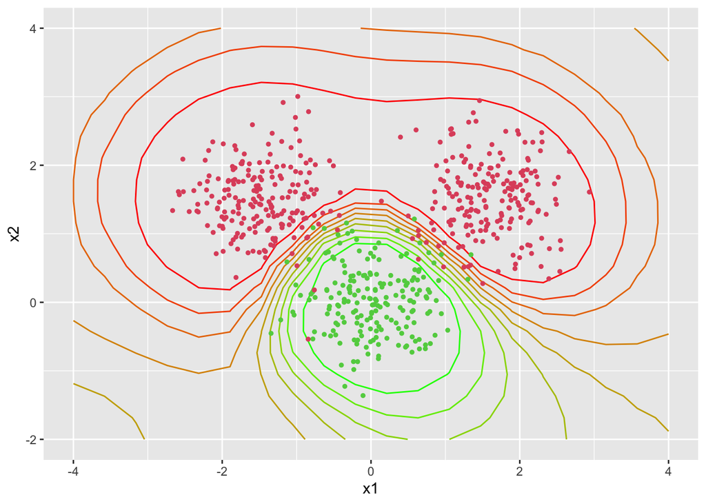

```r
# predict
ng <- 20
x1g <- seq(-4,4,len=ng)
x2g <- seq(-2,4,len=ng)

xnew <- cbind( rep(x1g,each=ng), rep(x2g,ng) )
pred <- gp_pred(gp, xnew, transform=T) #transform: transforms the draws of latent values to the same scale as the target, i.e. through the response (inverse-link) function
prob <- pred$mean

# visualize
ggplot() +
  geom_contour(data=data.frame(x=xnew[,1], y=xnew[,2], prob=prob),
                aes(x=x, y=y, z=prob, colour=..level..) ) +
  scale_colour_gradient(low = "red", high = "green", guide='none') +
  geom_point(data=data.frame(x=x[,1],y=x[,2]), aes(x=x,y=y), color=y+2, size=1) +
  xlab('x1') + ylab('x2')
```

# Sparse approximations

The package provides a few methods for handling bigger datasets for which the full GP inference is infeasible. This section illustrates with a synthetic 2d classification example.

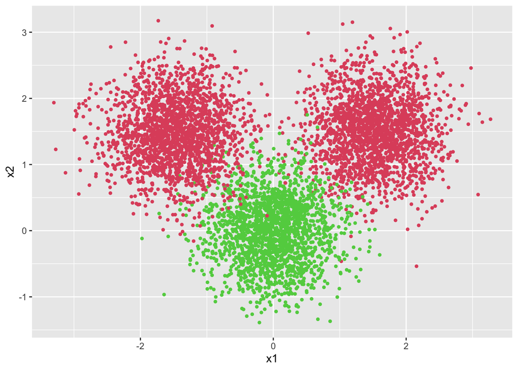

```r
# create synthetic 2d binary classification data
set.seed(2)
n <- 6000
n_per_cluster <- n/3
d <- 2
x <- 0.5*cbind( matrix(rnorm(n_per_cluster*d), nrow=d) + c(3,3),
                matrix(rnorm(n_per_cluster*d), nrow=d) - c(0,0),
                matrix(rnorm(n_per_cluster*d), nrow=d) + c(-3,3))
x <- t(x)
y <- c(rep(0,n_per_cluster), rep(1,n_per_cluster), rep(0,n_per_cluster))

# plot
ggplot() +
  geom_point(data=data.frame(x=x[,1],y=x[,2]), aes(x=x,y=y), color=y+2, size=1) +
  xlab('x1') + ylab('x2')
```

## FITC

The package implements a generic sparse approximation which is known as the fully independent training conditional, or FITC [@quinonero-candela2005; @snelson2006]. The accuracy of the approximation is determined by the number of inducing points. Notice that we use here only a relatively small number of inducing points to make this vignette build fast. In this toy example it does not affect the accuracy that much, but in more complicated example many more inducing points might be needed to get reasonable accuracy.

```r
# fit the model
gp <- gp_init(
  lik = lik_bernoulli(),
  cfs = cf_sexp(),
  method = method_fitc(num_inducing=50)
)
gp <- gp_optim(gp, x, y)
```

Let’s visualize the predictions.

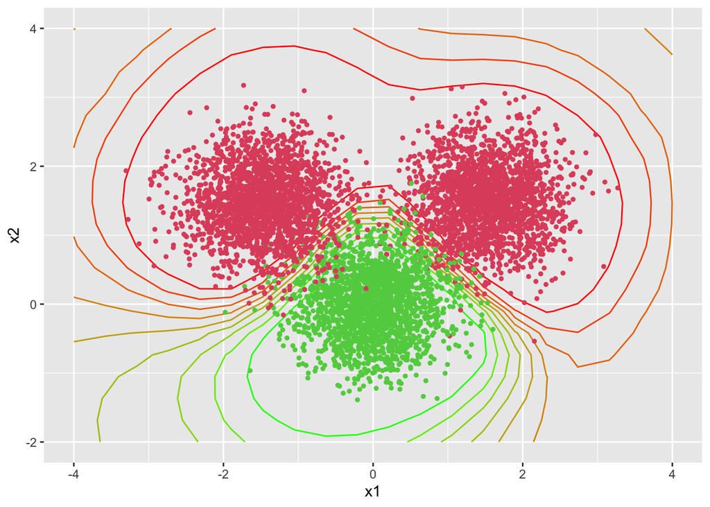

```r
# predict
ng <- 20
x1g <- seq(-4,4,len=ng)
x2g <- seq(-2,4,len=ng)

xnew <- cbind( rep(x1g,each=ng), rep(x2g,ng) )
pred <- gp_pred(gp, xnew, transform=T)
prob <- pred$mean

# visualize
ggplot() +
  geom_contour(data=data.frame(x=xnew[,1], y=xnew[,2], prob=prob),
                aes(x=x, y=y, z=prob, colour=..level..) ) +
  scale_colour_gradient(low = "red", high = "green", guide='none') +
  geom_point(data=data.frame(x=x[,1],y=x[,2]), aes(x=x,y=y), color=y+2, size=1) +
  xlab('x1') + ylab('x2')
```

The fit seems reasonably good even with only a small number of inducing points.

## Random features

The package also implements the method of random features [@rahimi2008]. The accuracy of the approximation is determined by the number of random features (also called basis functions). Again, we use a relatively small number of features, which works fine here, but in more complicated problems many more might be needed for reasonable accuracy.

```r
# fit the model
gp <- gp_init(
  cfs = cf_sexp(),
  lik = lik_bernoulli(),
  method = method_rf(num_basis=100)
)
gp <- gp_optim(gp, x, y, tol=1e-5)
```

Let’s again visualize the predictions.

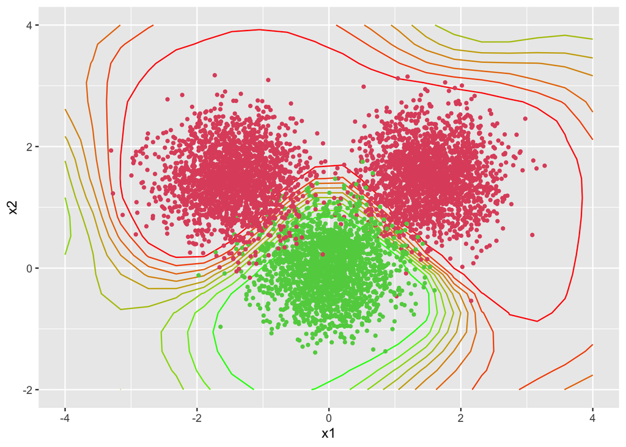

```r
# predict
ng <- 20
x1g <- seq(-4,4,len=ng)
x2g <- seq(-2,4,len=ng)

xnew <- cbind( rep(x1g,each=ng), rep(x2g,ng) )
pred <- gp_pred(gp, xnew, transform=T)
prob <- pred$mean

# visualize
ggplot() +
  geom_contour(data=data.frame(x=xnew[,1], y=xnew[,2], prob=prob),
                aes(x=x, y=y, z=prob, colour=..level..) ) +
  scale_colour_gradient(low = "red", high = "green", guide='none') +
  geom_point(data=data.frame(x=x[,1],y=x[,2]), aes(x=x,y=y), color=y+2, size=1) +
  xlab('x1') + ylab('x2')
```

The fit seems more or less reasonable, albeit the extrapolations outside the training data seem a bit wild compared to FITC. As a rule of thumb, the random features approach usually requires more basis functions than the FITC requires inducing inputs for comparable accuracy.